# **Unsupervise Learning Project - Customer Segmentation**

**Context**

AllLife Bank wants improve their credit card customer business based on the input from market research. In order to do that they want to run personalized campaigns to target new customers as well as upsell to existing customers. Also, their operations team wants to upgrade the service delivery model, to ensure that customer queries are resolved faster.

**Objective**

To identify different segments in the existing customer, based on their spending patterns as well as past interaction with the bank, using clustering algorithms, and provide recommendations to the bank on how to better market to and service these customers.

**Data Dictionary**

Sl_No: Primary key of the records

Customer Key: Customer identification number

Average Credit Limit: Average credit limit of each customer for all credit cards

Total credit cards: Total number of credit cards possessed by the customer

Total visits bank: Total number of visits that customer made (yearly) personally to the bank

Total visits online: Total number of visits or online logins made by the customer (yearly)

Total calls made: Total number of calls made by the customer to the bank or its customer service department (yearly)

# **1. Loading Required Libraries and Importing Data**

```python
# Importing libraries to help with reading and manipulating data
import numpy as np
import pandas as pd

# Importing Libraries to help with EDA
import matplotlib.pyplot as plt
import seaborn as sns
%matplotlib inline
sns.set()

# Removes the limit for the number of displayed columns
pd.set_option("display.max_columns", None)
# Sets the limit for the number of displayed rows
pd.set_option("display.max_rows", 500)

# to split the data into train and test
from sklearn.model_selection import train_test_split


# to do the scaling
from scipy.stats import zscore

# to perform k-means clustering and compute silhouette scores
from sklearn.cluster import KMeans
from sklearn.metrics import silhouette_score
# to visualize the elbow curve and silhouette scores
from yellowbrick.cluster import KElbowVisualizer, SilhouetteVisualizer
# to compute distances
from scipy.spatial.distance import cdist

from scipy.cluster.hierarchy import dendrogram, linkage, cophenet
from scipy.spatial.distance import pdist

from sklearn.cluster import AgglomerativeClustering

from sklearn.decomposition import PCA

import warnings
warnings.filterwarnings("ignore")
```

```python
# Connect to Google Drive
from google.colab import drive
drive.mount('/content/drive')
```

```python
# Create DataFrame 'ccd' by importing 'credit card data' file and make a copy of it just in case if need to revert back
ccd = pd.read_excel('/content/drive/My Drive/Colab Notebooks/credit_card_data.xlsx',sheet_name='Sheet1')
ccd_copy = ccd.copy()
```

# **2. Exploring Data At High Level**

Check first 10 records to see the dataset at high level

```python
ccd.head(10)
```

|  | Sl_No | Customer Key | Avg_Credit_Limit | Total_Credit_Cards | Total_visits_bank | Total_visits_online | Total_calls_made |
| --- | --- | --- | --- | --- | --- | --- | --- |
| 0 | 1 | 87073 | 100000 | 2 | 1 | 1 | 0 |
| 1 | 2 | 38414 | 50000 | 3 | 0 | 10 | 9 |
| 2 | 3 | 17341 | 50000 | 7 | 1 | 3 | 4 |
| 3 | 4 | 40496 | 30000 | 5 | 1 | 1 | 4 |
| 4 | 5 | 47437 | 100000 | 6 | 0 | 12 | 3 |
| 5 | 6 | 58634 | 20000 | 3 | 0 | 1 | 8 |
| 6 | 7 | 48370 | 100000 | 5 | 0 | 11 | 2 |
| 7 | 8 | 37376 | 15000 | 3 | 0 | 1 | 1 |
| 8 | 9 | 82490 | 5000 | 2 | 0 | 2 | 2 |
| 9 | 10 | 44770 | 3000 | 4 | 0 | 1 | 7 |

By looking at sample records, at a first glace data looks good and as per the data dictionary.

Let's check few basic things to understand the dataset better.

```python
# checking for dups
ccd.duplicated().sum()
```

```
0
```

There are no duplicates

```python
# checking rows and columns of dataframe
ccd.shape
```

```
(660, 7)
```

There are 660 rows and 7 columns

```python
# check datatypes and non null counts
ccd.info()
```

```
<class 'pandas.core.frame.DataFrame'>
RangeIndex: 660 entries, 0 to 659
Data columns (total 7 columns):
 #   Column               Non-Null Count  Dtype
---  ------               --------------  -----
 0   Sl_No                660 non-null    int64
 1   Customer Key         660 non-null    int64
 2   Avg_Credit_Limit     660 non-null    int64
 3   Total_Credit_Cards   660 non-null    int64
 4   Total_visits_bank    660 non-null    int64
 5   Total_visits_online  660 non-null    int64
 6   Total_calls_made     660 non-null    int64
dtypes: int64(7)
memory usage: 36.2 KB
```

Looks like all the column datatypes as expected and there are no nulls in the dataset either.

```python
# check some stats of columns
ccd.describe(include="all").T
```

|  | count | mean | std | min | 25% | 50% | 75% | max |
| --- | --- | --- | --- | --- | --- | --- | --- | --- |
| Sl_No | 660.0 | 330.500000 | 190.669872 | 1.0 | 165.75 | 330.5 | 495.25 | 660.0 |
| Customer Key | 660.0 | 55141.443939 | 25627.772200 | 11265.0 | 33825.25 | 53874.5 | 77202.50 | 99843.0 |
| Avg_Credit_Limit | 660.0 | 34574.242424 | 37625.487804 | 3000.0 | 10000.00 | 18000.0 | 48000.00 | 200000.0 |
| Total_Credit_Cards | 660.0 | 4.706061 | 2.167835 | 1.0 | 3.00 | 5.0 | 6.00 | 10.0 |
| Total_visits_bank | 660.0 | 2.403030 | 1.631813 | 0.0 | 1.00 | 2.0 | 4.00 | 5.0 |
| Total_visits_online | 660.0 | 2.606061 | 2.935724 | 0.0 | 1.00 | 2.0 | 4.00 | 15.0 |
| Total_calls_made | 660.0 | 3.583333 | 2.865317 | 0.0 | 1.00 | 3.0 | 5.00 | 10.0 |

Few observations -

1) Average credit limit of customers varies between 3k to 200k with median at around 18k. Looks like there would be some outliers.

2) Most of the customers carry around 5 credit cards with some at 10, there could be some outliers here as well.

3) Total yearly customer in-person visits are between 0 and 5 and online visits are between 0 and 15. However, 75% customers visit 4 times (both in-person and online)

4) Total calls made are between 0 and 10 with mean and median around 3.

**Pre EDA Data Pre Processing**

Sl_No can be dropped as it would not add any value in Modelling and would not be required for EDA as well. So it is better to drop at this point.

```python
# dropping ID column in original dataset
ccd.drop(columns='Sl_No', inplace=True)
```

Sl_No was the primary key of dataset, let's see if there are any duplicates after it was dropped.

Customer Key is also not going to be useful in EDA and modelling as it is just identification number. However, I would not like to drop it completely as it could be useful after the segmentation later.

I would like to create another dataset without 'Customer Key' and use that for EDA and further and then use ccd when the segments are ready.

```python
# create ccdattr with only feature columns
ccdattr = ccd.iloc[:,1:]
```

```python
# check data one more time
ccdattr.head()
```

|  | Avg_Credit_Limit | Total_Credit_Cards | Total_visits_bank | Total_visits_online | Total_calls_made |
| --- | --- | --- | --- | --- | --- |
| 0 | 100000 | 2 | 1 | 1 | 0 |
| 1 | 50000 | 3 | 0 | 10 | 9 |
| 2 | 50000 | 7 | 1 | 3 | 4 |
| 3 | 30000 | 5 | 1 | 1 | 4 |
| 4 | 100000 | 6 | 0 | 12 | 3 |

Looks good, let's do EDA.

# **3. Exploratory Data Analysis (EDA)**

### Univariate Analysis

Let's create function to find counts/percentage of columns with continuous values to understand the data better.

```python
def histogram_boxplot(data, feature, figsize=(12, 7), kde=False, bins=None):
    """
    Boxplot and histogram combined

    data: dataframe
    feature: dataframe column
    figsize: size of figure (default (12,7))
    kde: whether to show the density curve (default False)
    bins: number of bins for histogram (default None)
    """
    f2, (ax_box2, ax_hist2) = plt.subplots(
        nrows=2,  # Number of rows of the subplot grid= 2
        sharex=True,  # x-axis will be shared among all subplots
        gridspec_kw={"height_ratios": (0.25, 0.75)},
        figsize=figsize)  # creating the 2 subplots

    sns.boxplot(data=data, x=feature, ax=ax_box2, showmeans=True, color="violet")  # boxplot will be created and a star will indicate the mean value of the column

    if bins:
      sns.histplot(data=data, x=feature, kde=kde, ax=ax_hist2, bins=bins, palette="winter")
    else:
      sns.histplot(data=data, x=feature, kde=kde, ax=ax_hist2)  # For histogram

    ax_hist2.axvline(data[feature].mean(), color="green", linestyle="--")  # Add mean to the histogram

    ax_hist2.axvline(data[feature].median(), color="black", linestyle="-")  # Add median to the histogram
```

**Avg_Credit_Limit**

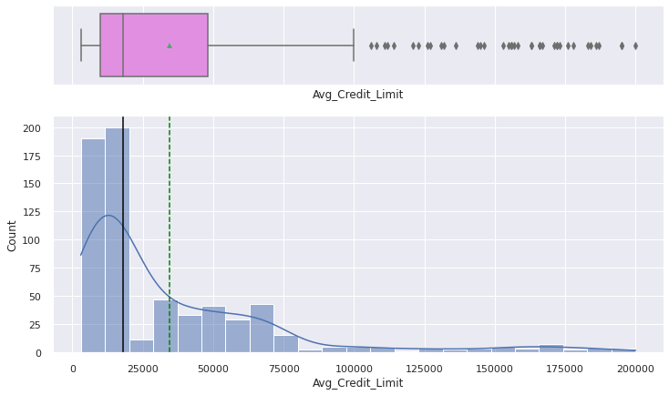

```python
histogram_boxplot(ccdattr,'Avg_Credit_Limit',kde=True)
```

Average credit limit is right skewed with many outliers after right whisker.

**Total_Credit_Cards**

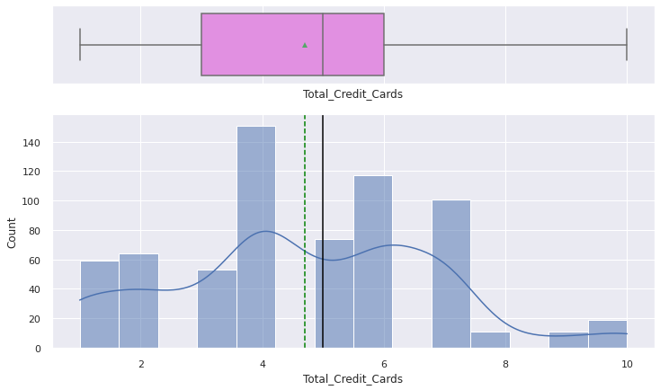

```python
histogram_boxplot(ccdattr,'Total_Credit_Cards',kde=True)
```

It has couple of peaks and valleys with max customers are around 4 credit cards.

**Total_visits_bank**

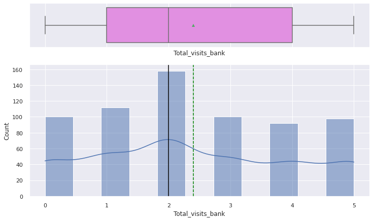

```python
histogram_boxplot(ccdattr,'Total_visits_bank',kde=True)
```

It kind of looks normalized curve with higest at visits at 2.

**Total_visits_online**

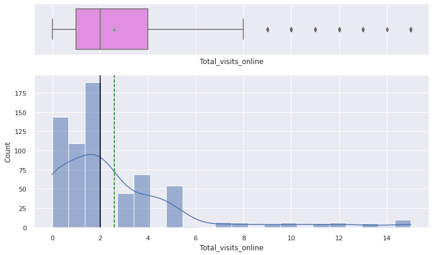

```python
histogram_boxplot(ccdattr,'Total_visits_online',kde=True)
```

Online visits are right skewed and has some outlier after right whisker.

**Total_calls_made**

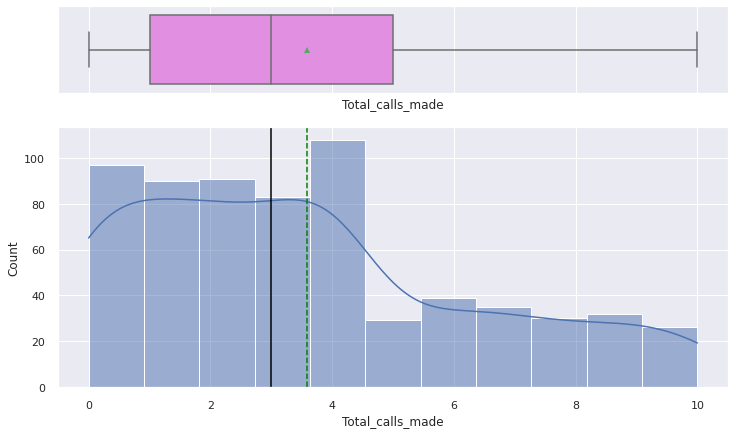

```python
histogram_boxplot(ccdattr,'Total_calls_made',kde=True)
```

Majorty of data are within 4 calls and median is around 3.

Rest of the integer columns are having handful of values. Let's create function to find counts/percentage for these columns to map their unique values to understand them better.

```python
# function to create labeled countplots

def labeled_countplot(data, feature, hue=None, perc=False, n=None):
    """
    Barplot with percentage at the top

    data: dataframe
    feature: dataframe column
    perc: whether to display percentages instead of count (default is False)
    n: displays the top n category levels (default is None, i.e., display all levels)
    """

    total = len(data[feature])  # length of the column
    count = data[feature].nunique()
    if n is None:
        plt.figure(figsize=(count + 1, 5))
    else:
        plt.figure(figsize=(n + 1, 5))

    plt.xticks(rotation=90, fontsize=15)
    if hue==None:
      ax = sns.countplot(
        data=data,
        x=feature,
        palette="Paired",
        order=data[feature].value_counts().index[:n].sort_values(),
      )
    else:
      ax = sns.countplot(
        data=data,
        x=feature,
        hue=hue,
        palette="Paired",
        order=data[feature].value_counts().index[:n].sort_values(),
      )

    for p in ax.patches:
        if perc == True:
            label = "{:.1f}%".format(
                100 * p.get_height() / total
            )  # percentage of each class of the category
        else:
            label = p.get_height()  # count of each level of the category

        x = p.get_x() + p.get_width() / 2  # width of the plot
        y = p.get_height()  # height of the plot

        ax.annotate(
            label,
            (x, y),
            ha="center",
            va="center",
            size=12,
            xytext=(0, 5),
            textcoords="offset points",
        )  # annotate the percentage

    plt.show()  # show the plot
```

Let's map rest of the columns

**Total_Credit_Cards**

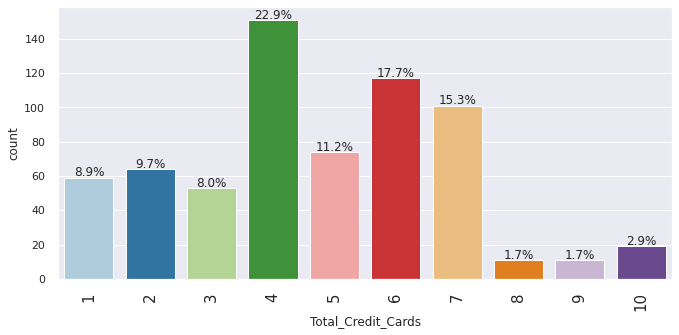

```python
labeled_countplot(ccdattr,'Total_Credit_Cards',perc=True, n=10)
```

Highest customers having 4 credit cards with few having 10.

**Total_visits_bank**

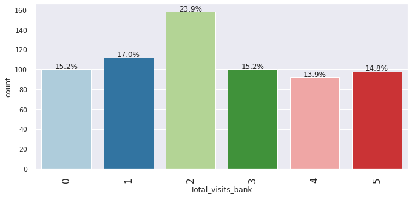

```python
labeled_countplot(ccdattr,'Total_visits_bank', perc=True,n=10)
```

No bad data. Highest number of customers visit in person 2 times. Rest of the visits kind of divided equally.

**Total_visits_online**

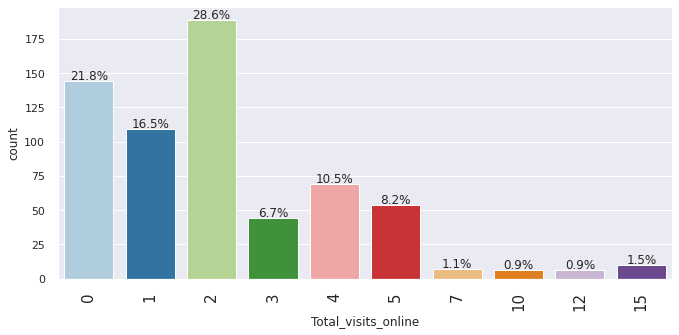

```python
labeled_countplot(ccdattr,'Total_visits_online', perc=True, n=10)
```

No bad data. Same like in-person, highest customers visit online twice a year, followed by 0. Very few visits as more as 15 times.

**Total_calls_made**

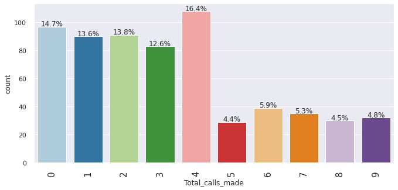

```python
labeled_countplot(ccdattr,'Total_calls_made', perc=True, n=10)
```

No bad data. Around 75% customers make calls between 0 and 4 with majority at 4. Total number of calls reduce after 4.

### Bivariate Analysis

Let's start by finding the correlations between different columns to get generic idea.

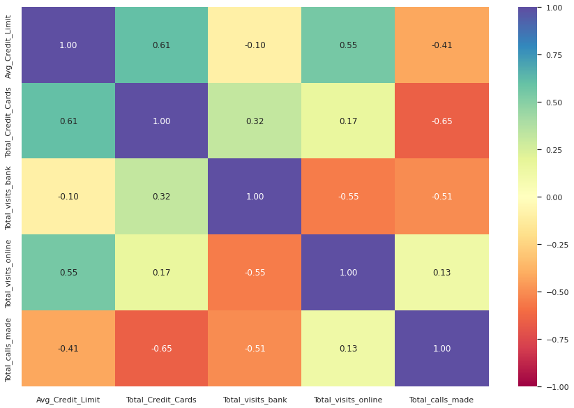

```python
plt.figure(figsize=(15, 10))
sns.heatmap(
    ccdattr.corr(), annot=True, vmin=-1, vmax=1, fmt=".2f", cmap="Spectral"
)
plt.show()
```

Few observations -

1) Total visit to bank is negatively correlated with total visits online and total calls made to the bank and it makes sense, when customer visits in person, it reduces the need to call customer service or do stuff online.

2) Total calls made is negatively correlated with total number of credit cards that customer has. Kind of strange when customers own more credit cards, they do less calls to the bank. May be they understand the process very well and have less queries compare to customers with less number of credit cards.

3) Avg credit limit is positively correlated with total credit card cusotmer has, makes sense.

4) Total visits online is positively correlated with average credit limit. Higher the credit limit higher the online visits of customer.

Let's build pairplot to analyze more.

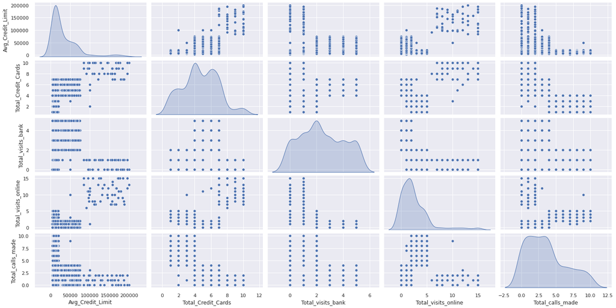

```python
#building pairplot of all attributes
sns.pairplot(ccdattr, height=2,aspect=2 , diag_kind='kde')
```

Few Observations -

1) Total calls made decreases to half when visits to the bank goes 3 or above.

2) Customers having 4 to 8 cards make maximum visits to the bank. 7 and above customers do more online visits.

3) After 75k average credit limit, the total number of credit cards and online visits increases and same time total calls made and visits to the bank decreases.

Saw positive correlation between total number of credit cards and average credit limit earlier, let's plot them to see further.

**Total_Credit_Cards vs. Avg_Credit_Limit**

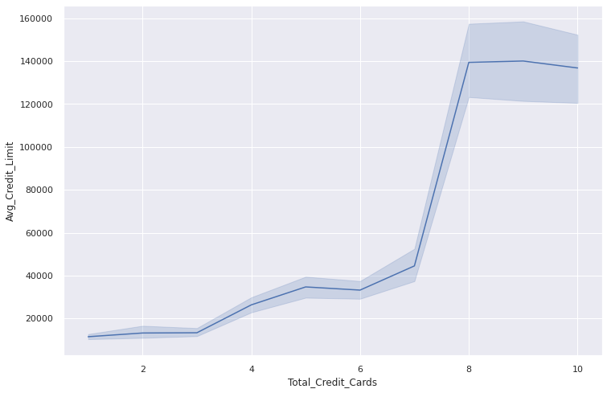

```python
plt.figure(figsize=(12, 8))
sns.lineplot(data=ccd,x='Total_Credit_Cards',y='Avg_Credit_Limit')
plt.show()
```

As expected, average credit limit increases with the increase of credit card count. However, the avg credit limit shoots up when customers credit cards count goes from 7 to 8 and then becomes stable.

### Summary of Observations of EDA

Avg Credit Limit - customers are divided across different credit limits and right skewed. Most of them are below 25k but has many outliers and can go all the way up to 200k.

Total Visits Bank - it varies kind of evenly between 0 and 5. It is negatively correlated with online visits and calls made by customer.

Total Visits Online - More than 50% customers use online banking 2 or less times. However, customers with higher credit limit uses more often compare to less credit limit customers.

None of the columns having bad data that has to be treated. There are some outliers in few columns and it would be checked later to see if its valid or not.

# **4. Data Pre-Processing**

### Missing Values

As observed in 'Exploring Data At High Level' section, there were no nulls in any columns. Let's confirm.

```python
ccd.isna().sum()
```

```
Customer Key           0
Avg_Credit_Limit       0
Total_Credit_Cards     0
Total_visits_bank      0
Total_visits_online    0
Total_calls_made       0
dtype: int64
```

Looks good. No actions required.

### Outlier Detection and Treatment

Let's check outliers found in EDA section - Avg_Credit_Limit & Total_visit_online

**Avg_Credit_Limit**

During EDA, it was observed there were many records right after right whisker uptil around 100K mark. Let's check those records.

```python
ccd.loc[ccd['Avg_Credit_Limit']>100000]
```

|  | Customer Key | Avg_Credit_Limit | Total_Credit_Cards | Total_visits_bank | Total_visits_online | Total_calls_made |
| --- | --- | --- | --- | --- | --- | --- |
| 612 | 94391 | 157000 | 9 | 1 | 14 | 1 |
| 614 | 40019 | 163000 | 8 | 1 | 7 | 1 |
| 615 | 77910 | 131000 | 9 | 1 | 10 | 1 |
| 617 | 98216 | 136000 | 8 | 0 | 13 | 0 |
| 618 | 54495 | 121000 | 7 | 0 | 13 | 2 |
| 619 | 47650 | 158000 | 7 | 0 | 13 | 0 |
| 620 | 32107 | 108000 | 10 | 0 | 15 | 1 |
| 621 | 84192 | 166000 | 9 | 1 | 12 | 2 |
| 622 | 53916 | 176000 | 10 | 1 | 15 | 2 |
| 623 | 32584 | 166000 | 10 | 0 | 7 | 0 |
| 624 | 97285 | 178000 | 7 | 0 | 11 | 0 |
| 626 | 15585 | 156000 | 9 | 1 | 10 | 2 |
| 627 | 20620 | 146000 | 10 | 0 | 12 | 1 |
| 629 | 76203 | 155000 | 8 | 0 | 7 | 2 |
| 630 | 33837 | 200000 | 10 | 0 | 13 | 0 |
| 631 | 14916 | 195000 | 8 | 0 | 15 | 0 |
| 632 | 97935 | 187000 | 7 | 1 | 7 | 0 |
| 633 | 16180 | 163000 | 7 | 1 | 10 | 1 |
| 634 | 49493 | 106000 | 8 | 0 | 8 | 1 |
| 635 | 70974 | 114000 | 10 | 1 | 7 | 2 |
| 636 | 40217 | 126000 | 10 | 1 | 8 | 0 |
| 637 | 88442 | 173000 | 9 | 1 | 11 | 0 |
| 638 | 17538 | 153000 | 8 | 1 | 7 | 1 |
| 639 | 90839 | 184000 | 7 | 1 | 15 | 2 |
| 640 | 99843 | 123000 | 8 | 1 | 15 | 2 |
| 641 | 27212 | 144000 | 10 | 0 | 10 | 2 |
| 644 | 18519 | 127000 | 10 | 1 | 15 | 1 |
| 645 | 48762 | 171000 | 10 | 0 | 15 | 0 |
| 646 | 58392 | 186000 | 7 | 0 | 8 | 1 |
| 647 | 79953 | 183000 | 9 | 0 | 9 | 2 |
| 648 | 13315 | 111000 | 8 | 1 | 7 | 0 |
| 649 | 30570 | 112000 | 10 | 1 | 8 | 1 |
| 650 | 78996 | 195000 | 10 | 1 | 12 | 2 |
| 651 | 78404 | 132000 | 9 | 1 | 12 | 2 |
| 652 | 28525 | 156000 | 8 | 1 | 8 | 0 |
| 654 | 65750 | 172000 | 10 | 1 | 9 | 1 |
| 657 | 53834 | 145000 | 8 | 1 | 9 | 1 |
| 658 | 80655 | 172000 | 10 | 1 | 15 | 0 |
| 659 | 80150 | 167000 | 9 | 0 | 12 | 2 |

All these 39 records look OK to me as higher credit limit customers have higher number of credit cards also, so it doesn't look like a bad data. I would like to leave those alone and do not treat them anyway.

**Total_visits_online**

In EDA section we saw the outliers after 8. Let's observe these records.

```python
ccd.loc[ccd['Total_visits_online']>8]
```

|  | Customer Key | Avg_Credit_Limit | Total_Credit_Cards | Total_visits_bank | Total_visits_online | Total_calls_made |
| --- | --- | --- | --- | --- | --- | --- |
| 1 | 38414 | 50000 | 3 | 0 | 10 | 9 |
| 4 | 47437 | 100000 | 6 | 0 | 12 | 3 |
| 6 | 48370 | 100000 | 5 | 0 | 11 | 2 |
| 612 | 94391 | 157000 | 9 | 1 | 14 | 1 |
| 613 | 50598 | 94000 | 9 | 1 | 11 | 0 |
| 615 | 77910 | 131000 | 9 | 1 | 10 | 1 |
| 616 | 89832 | 96000 | 10 | 1 | 11 | 2 |
| 617 | 98216 | 136000 | 8 | 0 | 13 | 0 |
| 618 | 54495 | 121000 | 7 | 0 | 13 | 2 |
| 619 | 47650 | 158000 | 7 | 0 | 13 | 0 |
| 620 | 32107 | 108000 | 10 | 0 | 15 | 1 |
| 621 | 84192 | 166000 | 9 | 1 | 12 | 2 |
| 622 | 53916 | 176000 | 10 | 1 | 15 | 2 |
| 624 | 97285 | 178000 | 7 | 0 | 11 | 0 |
| 626 | 15585 | 156000 | 9 | 1 | 10 | 2 |
| 627 | 20620 | 146000 | 10 | 0 | 12 | 1 |
| 628 | 75009 | 84000 | 9 | 1 | 15 | 0 |
| 630 | 33837 | 200000 | 10 | 0 | 13 | 0 |
| 631 | 14916 | 195000 | 8 | 0 | 15 | 0 |
| 633 | 16180 | 163000 | 7 | 1 | 10 | 1 |
| 637 | 88442 | 173000 | 9 | 1 | 11 | 0 |
| 639 | 90839 | 184000 | 7 | 1 | 15 | 2 |
| 640 | 99843 | 123000 | 8 | 1 | 15 | 2 |
| 641 | 27212 | 144000 | 10 | 0 | 10 | 2 |
| 642 | 91575 | 97000 | 10 | 1 | 9 | 2 |
| 644 | 18519 | 127000 | 10 | 1 | 15 | 1 |
| 645 | 48762 | 171000 | 10 | 0 | 15 | 0 |
| 647 | 79953 | 183000 | 9 | 0 | 9 | 2 |
| 650 | 78996 | 195000 | 10 | 1 | 12 | 2 |
| 651 | 78404 | 132000 | 9 | 1 | 12 | 2 |
| 653 | 51826 | 95000 | 10 | 0 | 15 | 1 |
| 654 | 65750 | 172000 | 10 | 1 | 9 | 1 |
| 655 | 51108 | 99000 | 10 | 1 | 10 | 0 |
| 656 | 60732 | 84000 | 10 | 1 | 13 | 2 |
| 657 | 53834 | 145000 | 8 | 1 | 9 | 1 |
| 658 | 80655 | 172000 | 10 | 1 | 15 | 0 |
| 659 | 80150 | 167000 | 9 | 0 | 12 | 2 |

For above 37 records, customers visit online is more, but has very less in-person visits and calls to the bank. And in a year online visit max count is 15, which little more than once a month, which is not that high. I would leave it alone and not treat these outliers.

### Feature Engineering

**Scaling**

As in unsupervised learning, the distance between 2 data points are very important, it is required to see if all the features use same metrics. The dataset has 5 features, let's check those once.

```python
ccdattr.head()
```

|  | Avg_Credit_Limit | Total_Credit_Cards | Total_visits_bank | Total_visits_online | Total_calls_made |
| --- | --- | --- | --- | --- | --- |
| 0 | 100000 | 2 | 1 | 1 | 0 |
| 1 | 50000 | 3 | 0 | 10 | 9 |
| 2 | 50000 | 7 | 1 | 3 | 4 |
| 3 | 30000 | 5 | 1 | 1 | 4 |
| 4 | 100000 | 6 | 0 | 12 | 3 |

Except Avg_Credit_Limit, all features use the same metric. Avg_Credit_Limit uses dollar amount and the difference between 2 data points in Avg_Credit_Limit is so high compare to other feature, it would dominate other features, so we need to scale the dataset before we start using clustering techniques.

Let's scale the data using zscore that we imported earlier.

```python
# scaling dataset
ccdattrscaled = ccdattr.apply(zscore)
```

Let's check the sample data.

```python
ccdattrscaled.head()
```

|  | Avg_Credit_Limit | Total_Credit_Cards | Total_visits_bank | Total_visits_online | Total_calls_made |
| --- | --- | --- | --- | --- | --- |
| 0 | 1.740187 | -1.249225 | -0.860451 | -0.547490 | -1.251537 |
| 1 | 0.410293 | -0.787585 | -1.473731 | 2.520519 | 1.891859 |
| 2 | 0.410293 | 1.058973 | -0.860451 | 0.134290 | 0.145528 |
| 3 | -0.121665 | 0.135694 | -0.860451 | -0.547490 | 0.145528 |
| 4 | 1.740187 | 0.597334 | -1.473731 | 3.202298 | -0.203739 |

Looks good, the difference between data points in each feature is at same level.

### Duplicate Observation Check

Earlier we checked for duplicates in the whole dataset and we found none. However, we deleted the primary key (Sl_No), we should check if there are any duplicates after that.

```python
ccd.duplicated().sum()
```

```
0
```

Still no duplicates at entire row level so that's good. However, the data is at customer key level, so need to check if there multiple records for same 'customer key'. We saw earlier that there are 660 records in the dataset, let's check the number of unique records for customer key.

```python
ccd['Customer Key'].nunique()
```

```
655
```

Looks like there are 5 duplicates.

```python
#checking duplicate records
cust_key = ccd['Customer Key']
ccd[cust_key.isin(cust_key[cust_key.duplicated()])].sort_values("Customer Key")
```

|  | Customer Key | Avg_Credit_Limit | Total_Credit_Cards | Total_visits_bank | Total_visits_online | Total_calls_made |
| --- | --- | --- | --- | --- | --- | --- |
| 48 | 37252 | 6000 | 4 | 0 | 2 | 8 |
| 432 | 37252 | 59000 | 6 | 2 | 1 | 2 |
| 4 | 47437 | 100000 | 6 | 0 | 12 | 3 |
| 332 | 47437 | 17000 | 7 | 3 | 1 | 0 |
| 411 | 50706 | 44000 | 4 | 5 | 0 | 2 |
| 541 | 50706 | 60000 | 7 | 5 | 2 | 2 |
| 391 | 96929 | 13000 | 4 | 5 | 0 | 0 |
| 398 | 96929 | 67000 | 6 | 2 | 2 | 2 |
| 104 | 97935 | 17000 | 2 | 1 | 2 | 10 |
| 632 | 97935 | 187000 | 7 | 1 | 7 | 0 |

Each of above 5 customers have 2 different values on features. It could be because of any different reasons. Like, either there is a typo and wrong customer key is assigned to one out of two values or one of them is older record of that customer and second is updated record or some issue while creating dataset etc.

In either case, there are just 10 records, I can simply delete them, however the goal of the project is do the clustering on different algorithms and for that I really do not need customer key, so these bad data can't harm that and I can use this data. There are already very less records in the dataset to begin with so I do not want to delete these records to make it even lesser dataset.

# **5. K-Means Clustering**

**Finding appropriate number of clusters**

K-means clustering technique requires to have number of clusters pre determined. To find the right number of clusters, let's use elbow method curve by taking clusters between 1 and 8.

```
Number of Clusters: 1 	Average Distortion: 2.006922226250361
Number of Clusters: 2 	Average Distortion: 1.4571553548514269
Number of Clusters: 3 	Average Distortion: 1.1466276549150365
Number of Clusters: 4 	Average Distortion: 1.0463825294774465
Number of Clusters: 5 	Average Distortion: 0.9907468928853336
Number of Clusters: 6 	Average Distortion: 0.9431590010817001
Number of Clusters: 7 	Average Distortion: 0.9095661498049185
Number of Clusters: 8 	Average Distortion: 0.8921731743830527
```

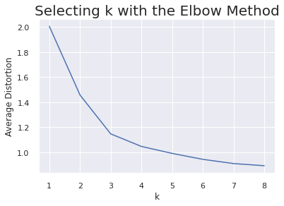

```python
clusters = range(1, 9)
meanDistortions = []  # Create a empty list

for k in clusters:
    model = KMeans(n_clusters=k)  # Initialize KMeans
    model.fit(ccdattrscaled)  # Fit kMeans on the data
    prediction = model.predict(ccdattrscaled)  # Predict the model on the data
    distortion = (
        sum(np.min(cdist(ccdattrscaled, model.cluster_centers_, "euclidean"), axis=1))
        / ccdattrscaled.shape[0]  # Find distortion
    )

    meanDistortions.append(
        distortion
    )  # Append distortion values to the empty list created above

    print("Number of Clusters:", k, "\tAverage Distortion:", distortion)

plt.plot(clusters, meanDistortions, "bx-")
plt.xlabel("k")  # Title of X-axis
plt.ylabel("Average Distortion")  # Title of y-axis
plt.title("Selecting k with the Elbow Method", fontsize=20)  # Title of the plot
```

The above graph shows the clear elow at 3 and slight at 4. Let's find the silhouette scores for clusters 2 to 8

```
For n_clusters = 2, silhouette score is 0.41842496663215445
For n_clusters = 3, silhouette score is 0.5157182558881063
For n_clusters = 4, silhouette score is 0.3556670619372605
For n_clusters = 5, silhouette score is 0.2717470361089752
For n_clusters = 6, silhouette score is 0.25545029453623114
For n_clusters = 7, silhouette score is 0.2481797343624604
For n_clusters = 8, silhouette score is 0.22706891053474995
For n_clusters = 9, silhouette score is 0.21869369635760347
```

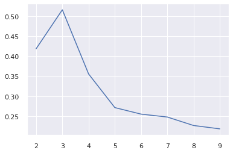

```python
sil_score = []  # Create empty list
cluster_list = list(range(2, 10))  # Creating a list of range from 2 to 10
for n_clusters in cluster_list:
    clusterer = KMeans(n_clusters=n_clusters)  # Initializing KMeans algorithm
    preds = clusterer.fit_predict((ccdattrscaled))  # Predicting on the data
    # centers = clusterer.cluster_centers_
    score = silhouette_score(ccdattrscaled, preds)  # Cacalculating silhouette score
    sil_score.append(score)  # Appending silhouette score to empty list created above
    print("For n_clusters = {}, silhouette score is {}".format(n_clusters, score))

plt.plot(cluster_list, sil_score)
```

The highest silhouette score is at 3 (0.51). The silhouette score of 4 is at 0.35. Number of clusters = 3 would be a better choice. Let's visualize both 3 and 4 once also.

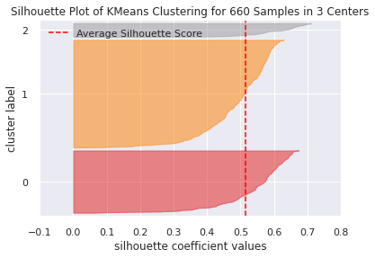

```python
# visualize silhouette coefficients wtih no. of clusters as 3
visualizer = SilhouetteVisualizer(KMeans(3, random_state=1))
visualizer.fit(ccdattrscaled)
visualizer.show()
```

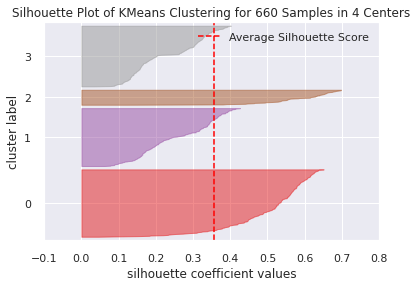

```python
# visualize silhouette coefficients wtih no. of clusters as 4
visualizer = SilhouetteVisualizer(KMeans(4, random_state=1))
visualizer.fit(ccdattrscaled)
visualizer.show()
```

Let's analyze few checkpoints of silhouette visualizer -

1) all the clusters should have higher than average silhouette score - both are good. However, 3 does better than 4.

2) no negative silhouette coefficent value - both are good.

3) all the clusters should have different width - 3 shows clear different width in all the clusters, however, 4 has kind of similar in at least two of them.

4) all the clusters should have different silhouette score - 3 does that clearly, however 4 has two clusters (#1 and #3) with quite similar.

From above, it looks like 3 is a clear winner and it has better elbow and more silhouette score. I would like to apply number of clusters = 3 to k-means algorithm.

**Applying KMeans clustering for k=3**

```python
# let's take 3 as number of clusters
kmeans = KMeans(n_clusters=3, random_state=0)
kmeans.fit(ccdattrscaled)
```

```
KMeans(n_clusters=3, random_state=0)
```

We have created 3 clusters and fitted that on scaled dataset. Let's add label column to the original, attr (the one with features only) and scaled dataframes.

As part of this project, we are going to try hierarchical clustering using the same dataset later, let me make copy of original, attr and scaled datasets first and add the lables colum to that, so the original versions do not change.

```python
# creating _k version of original datasets to use further in k-means
ccd_k = ccd.copy()
ccdattr_k = ccdattr.copy()
ccdattrscaled_k = ccdattrscaled.copy()
```

```python
# adding kmeans cluster labels to the original, attr and scaled dataframes

ccd_k["K_means_segments"] = kmeans.labels_
ccdattr_k["K_means_segments"] = kmeans.labels_
ccdattrscaled_k["K_means_segments"] = kmeans.labels_
```

Check once how original dataset looks.

```python
ccd_k.head()
```

|  | Customer Key | Avg_Credit_Limit | Total_Credit_Cards | Total_visits_bank | Total_visits_online | Total_calls_made | K_means_segments |
| --- | --- | --- | --- | --- | --- | --- | --- |
| 0 | 87073 | 100000 | 2 | 1 | 1 | 0 | 0 |
| 1 | 38414 | 50000 | 3 | 0 | 10 | 9 | 1 |
| 2 | 17341 | 50000 | 7 | 1 | 3 | 4 | 0 |
| 3 | 40496 | 30000 | 5 | 1 | 1 | 4 | 0 |
| 4 | 47437 | 100000 | 6 | 0 | 12 | 3 | 2 |

Looks as expected. Next, let's do cluster profiling.

**Cluster Profiling**

As we have added cluster labels to the datasets, let's get some stats on it.

```python
# create a variable to get the mean by grouping at label level
cluster_profile_k = ccd_k.groupby("K_means_segments").mean()
```

```python
# add another column to do the count
cluster_profile_k["count_in_each_segments"] = (
    ccd_k.groupby("K_means_segments")["Customer Key"].count().values
)
```

```python
# let's display cluster profiles
cluster_profile_k.style.highlight_max(color="lightgreen", axis=0)
```

| K_means_segments | Customer Key | Avg_Credit_Limit | Total_Credit_Cards | Total_visits_bank | Total_visits_online | Total_calls_made | count_in_each_segments |
| --- | --- | --- | --- | --- | --- | --- | --- |
| 0 | 54881.329016 | 33782.383420 | 5.515544 | 3.489637 | 0.981865 | 2.000000 | 386 |
| 1 | 55239.830357 | 12174.107143 | 2.410714 | 0.933036 | 3.553571 | 6.870536 | 224 |
| 2 | 56708.760000 | 141040.000000 | 8.740000 | 0.600000 | 10.900000 | 1.080000 | 50 |

Original dataset has been divided into clusters with counts of 386, 224 and 50. Most of the highest mean values fall into cluster 2. Cluster 0 has mid-range values and cluster 1 has low values except total calls made.

Next, let's plot each attribute by their clusters. First we try on scaled dataset and then original. Both should be similar or very close, but let's check it out.

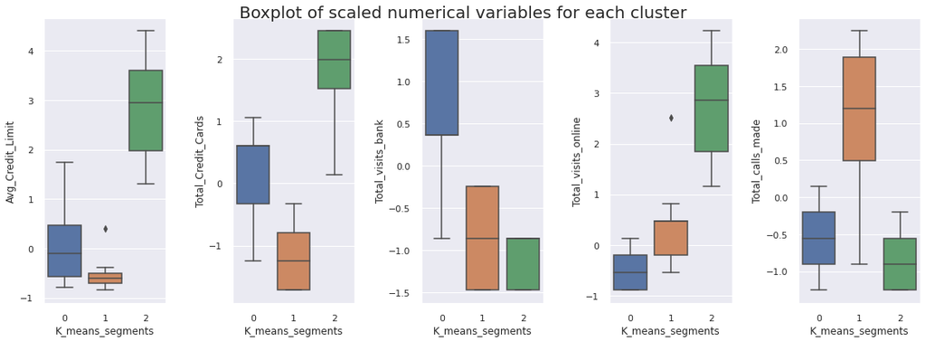

```python
# plotting scaled dataset
fig, axes = plt.subplots(1, 5, figsize=(16, 6))
fig.suptitle("Boxplot of scaled numerical variables for each cluster", fontsize=20)
counter = 0
for ii in range(5):
    sns.boxplot(
        ax=axes[ii],
        y=ccdattrscaled_k[list(ccdattrscaled_k.columns)[counter]],
        x=ccdattrscaled_k["K_means_segments"],
    )
    counter = counter + 1

fig.tight_layout(pad=2.0)
```

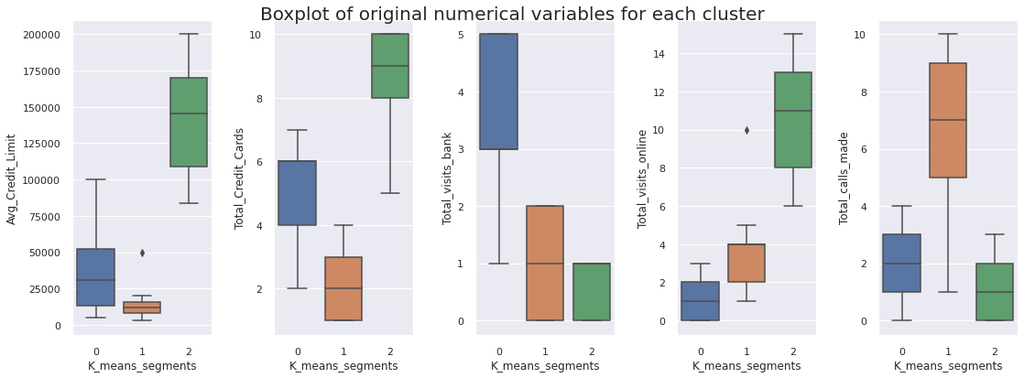

```python
# plotting original dataset
fig, axes = plt.subplots(1, 5, figsize=(16, 6))
fig.suptitle("Boxplot of original numerical variables for each cluster", fontsize=20)
counter = 1
for ii in range(5):
    sns.boxplot(ax=axes[ii], y=ccd_k[list(ccd_k.columns)[counter]], x=ccd_k["K_means_segments"])
    counter = counter + 1

fig.tight_layout(pad=2.0)
```

We can gather much insights from above box plots and I will explain those in detail in 'Insights' section, but before that let's also use describe to get the accurate stats on these clusters.

```python
# running describe on attr dataset
ccdattr_k.groupby("K_means_segments").describe().T
```

|  | K_means_segments | 0 | 1 | 2 |
| --- | --- | --- | --- | --- |
| Avg_Credit_Limit | count | 386.000000 | 224.000000 | 50.000000 |
|  | mean | 33782.383420 | 12174.107143 | 141040.000000 |
|  | std | 22169.460696 | 5249.048524 | 34457.877272 |
|  | min | 5000.000000 | 3000.000000 | 84000.000000 |
|  | 25% | 13000.000000 | 8000.000000 | 108750.000000 |
|  | 50% | 31000.000000 | 12000.000000 | 145500.000000 |
|  | 75% | 52000.000000 | 16000.000000 | 170000.000000 |
|  | max | 100000.000000 | 50000.000000 | 200000.000000 |
| Total_Credit_Cards | count | 386.000000 | 224.000000 | 50.000000 |
|  | mean | 5.515544 | 2.410714 | 8.740000 |
|  | std | 1.140069 | 1.100783 | 1.274715 |
|  | min | 2.000000 | 1.000000 | 5.000000 |
|  | 25% | 4.000000 | 1.000000 | 8.000000 |
|  | 50% | 6.000000 | 2.000000 | 9.000000 |
|  | 75% | 6.000000 | 3.000000 | 10.000000 |
|  | max | 7.000000 | 4.000000 | 10.000000 |
| Total_visits_bank | count | 386.000000 | 224.000000 | 50.000000 |
|  | mean | 3.489637 | 0.933036 | 0.600000 |
|  | std | 1.135563 | 0.803567 | 0.494872 |
|  | min | 1.000000 | 0.000000 | 0.000000 |
|  | 25% | 3.000000 | 0.000000 | 0.000000 |
|  | 50% | 3.000000 | 1.000000 | 1.000000 |
|  | 75% | 5.000000 | 2.000000 | 1.000000 |
|  | max | 5.000000 | 2.000000 | 1.000000 |
| Total_visits_online | count | 386.000000 | 224.000000 | 50.000000 |
|  | mean | 0.981865 | 3.553571 | 10.900000 |
|  | std | 0.857167 | 1.218978 | 2.880264 |
|  | min | 0.000000 | 1.000000 | 6.000000 |
|  | 25% | 0.000000 | 2.000000 | 8.000000 |
|  | 50% | 1.000000 | 4.000000 | 11.000000 |
|  | 75% | 2.000000 | 4.000000 | 13.000000 |
|  | max | 3.000000 | 10.000000 | 15.000000 |
| Total_calls_made | count | 386.000000 | 224.000000 | 50.000000 |
|  | mean | 2.000000 | 6.870536 | 1.080000 |
|  | std | 1.430648 | 1.990161 | 0.876915 |
|  | min | 0.000000 | 1.000000 | 0.000000 |
|  | 25% | 1.000000 | 5.000000 | 0.000000 |
|  | 50% | 2.000000 | 7.000000 | 1.000000 |
|  | 75% | 3.000000 | 9.000000 | 2.000000 |
|  | max | 4.000000 | 10.000000 | 3.000000 |

**Insights on each clusters**

**Cluster 0**

- This cluster has count of 386, which is highest among all 3 clusters.
- Average credit card limit is mid-range in this cluster with average around 33K and max at 100K.
- Total credit cards is also kind of mid-range, between 2-7 with majority at 6.
- Total visits to the bank is on higher side, with majority is 3 and minimum of 1.
- Total visits online is much lower in this cluster, includes data with all 0 visits as well and majority at 1.
- Total calls made is lower to mid in this cluster with average and median at 2.

**Cluster 1**

- This cluster has count of 224, which is in between of rest 2 clusters.
- Average credit limit is much lower in this cluster, with most less than 15K.
- Total credit cards is also in much lower side in this cluster, includes all the minimum values with median around 2
- Total visits to the bank is between 0 and 2 and average and median at 1.
- Total online visite are kind of mid-range in this cluster, more than cluster 0 and less than cluster 2. It includes an outlier at 10.
- Total calls made is at higher side on this cluster with average is close to 7 and highest is 10.

Overall, cluster 0 includes mid-level customers with mid level credit limit and number of cards, mid level visits etc and majority customers fall into this category. Cluster 1 includes the low credit limit, card and less visits to the bank kind of customers. Cluster 2 includes the least data but it includes customers with high limits, more cards and less calls made kind of customers, these customers are giving plenty of business with less overhead to the bank.

# **6. Hierarchical Clustering**

**Cophenetic Correlation and Dendograms**

In hierarchical clustering, the cophenetic correlation and dendogram help us to determind what distance metric and linkage method to use and also how many clusters to use.

It is important to find the right distance metrics and the linkage method to use for the algorithm. In order to do that, let's take 4 different distance metrics and 4 different linkage methods and find the cophenetic correlation with each of the possible combination, which is 4x4=16.

```python
# finding cophenetic correlation for total 16 combinations

# list of distance metrics
distance_metrics = ["euclidean", "chebyshev", "mahalanobis", "cityblock"]

# list of linkage methods
linkage_methods = ["single", "complete", "average", "weighted"]

high_cophenet_corr = 0
high_dm_lm = [0, 0]

for dm in distance_metrics:
    for lm in linkage_methods:
        Z = linkage(ccdattrscaled, metric=dm, method=lm)
        c, coph_dists = cophenet(Z, pdist(ccdattrscaled))
        print(
            "Cophenetic correlation for {} distance and {} linkage is {}.".format(
                dm.capitalize(), lm, c
            )
        )
        if high_cophenet_corr < c:
            high_cophenet_corr = c
            high_dm_lm[0] = dm
            high_dm_lm[1] = lm
```

```
Cophenetic correlation for Euclidean distance and single linkage is 0.7391220243806552.
Cophenetic correlation for Euclidean distance and complete linkage is 0.8599730607972423.
Cophenetic correlation for Euclidean distance and average linkage is 0.8977080867389372.
Cophenetic correlation for Euclidean distance and weighted linkage is 0.8861746814895477.
Cophenetic correlation for Chebyshev distance and single linkage is 0.7382354769296767.
Cophenetic correlation for Chebyshev distance and complete linkage is 0.8533474836336782.
Cophenetic correlation for Chebyshev distance and average linkage is 0.8974159511838106.
Cophenetic correlation for Chebyshev distance and weighted linkage is 0.8913624010768603.
Cophenetic correlation for Mahalanobis distance and single linkage is 0.7058064784553605.
Cophenetic correlation for Mahalanobis distance and complete linkage is 0.6663534463875359.
Cophenetic correlation for Mahalanobis distance and average linkage is 0.8326994115042136.
Cophenetic correlation for Mahalanobis distance and weighted linkage is 0.7805990615142518.
Cophenetic correlation for Cityblock distance and single linkage is 0.7252379350252723.
Cophenetic correlation for Cityblock distance and complete linkage is 0.8731477899179829.
Cophenetic correlation for Cityblock distance and average linkage is 0.896329431104133.
Cophenetic correlation for Cityblock distance and weighted linkage is 0.8825520731498188.
```

Let's print out the highest cophenetic correlation value.

```python
# printing the combination of distance metric and linkage method with the highest cophenetic correlation
print(
    "Highest cophenetic correlation is {}, which is obtained with {} distance and {} linkage.".format(
        high_cophenet_corr, high_dm_lm[0].capitalize(), high_dm_lm[1]
    )
)
```

```
Highest cophenetic correlation is 0.8977080867389372, which is obtained with Euclidean distance and average linkage.
```

Even though the highest cophenetic correlation value was found by Euclidean distance and average linkage, eucladiean distance can use other linkage methods like ward, weighted etc., let's try to find the cophenetic correlation scores for that as well by keeping distance metric as 'euclidean' only.

```python
# list of linkage methods
linkage_methods = ["single", "complete", "average", "centroid", "ward", "weighted"]

high_cophenet_corr = 0
high_dm_lm = [0, 0]

for lm in linkage_methods:
    Z = linkage(ccdattrscaled, metric="euclidean", method=lm)
    c, coph_dists = cophenet(Z, pdist(ccdattrscaled))
    print("Cophenetic correlation for {} linkage is {}.".format(lm, c))
    if high_cophenet_corr < c:
        high_cophenet_corr = c
        high_dm_lm[0] = "euclidean"
        high_dm_lm[1] = lm
```

```
Cophenetic correlation for single linkage is 0.7391220243806552.
Cophenetic correlation for complete linkage is 0.8599730607972423.
Cophenetic correlation for average linkage is 0.8977080867389372.
Cophenetic correlation for centroid linkage is 0.8939385846326323.
Cophenetic correlation for ward linkage is 0.7415156284827493.
Cophenetic correlation for weighted linkage is 0.8861746814895477.
```

Let's print out the highest cophenetic correlation value.

```python
# printing the combination of distance metric and linkage method with the highest cophenetic correlation
print(
    "Highest cophenetic correlation is {}, which is obtained with {} linkage.".format(
        high_cophenet_corr, high_dm_lm[1]
    )
)
```

```
Highest cophenetic correlation is 0.8977080867389372, which is obtained with average linkage.
```

Still the average linkage gave the best cophenetic correlation score.

Let's use the same different linkage methods that we used above and set the distance metric at euclediean and draw the dendograms for each combinations.

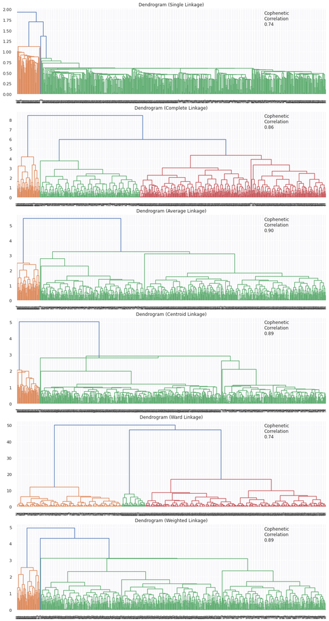

```python
# list of linkage methods
linkage_methods = ["single", "complete", "average", "centroid", "ward", "weighted"]

# lists to save results of cophenetic correlation calculation
compare_cols = ["Linkage", "Cophenetic Coefficient"]
compare = []

# to create a subplot image
fig, axs = plt.subplots(len(linkage_methods), 1, figsize=(15, 30))

# We will enumerate through the list of linkage methods above
# For each linkage method, we will plot the dendrogram and calculate the cophenetic correlation
for i, method in enumerate(linkage_methods):
    Z = linkage(ccdattrscaled, metric="euclidean", method=method)

    dendrogram(Z, ax=axs[i])
    axs[i].set_title(f"Dendrogram ({method.capitalize()} Linkage)")

    coph_corr, coph_dist = cophenet(Z, pdist(ccdattrscaled))
    axs[i].annotate(
        f"Cophenetic\nCorrelation\n{coph_corr:0.2f}",
        (0.80, 0.80),
        xycoords="axes fraction",
    )

    compare.append([method, coph_corr])
```

Let's print out cophenetic coefficient for above once.

```python
# comparing cophenetic correlations for each linkage method
df_cc = pd.DataFrame(compare, columns=compare_cols)
df_cc
```

|  | Linkage | Cophenetic Coefficient |
| --- | --- | --- |
| 0 | single | 0.739122 |
| 1 | complete | 0.859973 |
| 2 | average | 0.897708 |
| 3 | centroid | 0.893939 |
| 4 | ward | 0.741516 |
| 5 | weighted | 0.886175 |

Observations -

From above, ward and complete gave the best dendograms out of all with 3 clusters separated well.

Complete has better cophenetic correlation compare to ward. However, ward has much higher dendogram distance on y axis compare to complete.

Average linkage has the highest cohenetic coefficient but dendogram is not that good.

Before we take any decision, let's create few more dendograms. In the beginning of this section, when we tried 16 different combination, other than eucledien, distance metrics Chebyshev and CityBlock gave very close to high cohenetic correlation with average and weighted linkage methods. Let's plot their dendograms also.

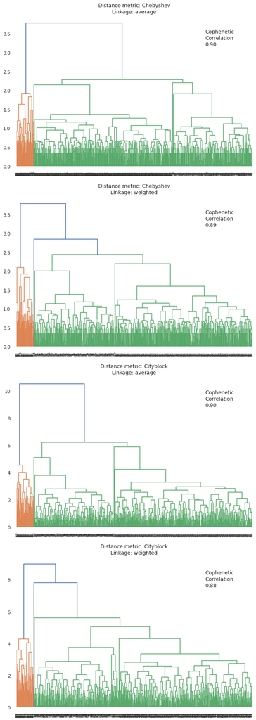

```python
# list of distance metrics
distance_metrics = ["chebyshev", "cityblock"]

# list of linkage methods
linkage_methods = ["average", "weighted"]

# to create a subplot image
fig, axs = plt.subplots(
    len(distance_metrics) + len(distance_metrics), 1, figsize=(10, 30)
)

i = 0
for dm in distance_metrics:
    for lm in linkage_methods:
        Z = linkage(ccdattrscaled, metric=dm, method=lm)

        dendrogram(Z, ax=axs[i])
        axs[i].set_title("Distance metric: {}\nLinkage: {}".format(dm.capitalize(), lm))

        coph_corr, coph_dist = cophenet(Z, pdist(ccdattrscaled))
        axs[i].annotate(
            f"Cophenetic\nCorrelation\n{coph_corr:0.2f}",
            (0.80, 0.80),
            xycoords="axes fraction",
        )
        i += 1
```

Out of all 4, chebyshev with average look the best but still its not as good as what we saw with ward because of dendogramic distance on y axis.

As it was seen in dendogram of distance metric of euclidean and linkage method of ward, it could cut horizontally at any point to give number of clusters. To find out what is the best way to cut it to get the best number of clusters, let's check silhouette score of each cluster.

```
For n_clusters = 2, silhouette score is 0.417704147620949
For n_clusters = 3, silhouette score is 0.5147639589977819
For n_clusters = 4, silhouette score is 0.3480822581261928
For n_clusters = 5, silhouette score is 0.2569177732675831
For n_clusters = 6, silhouette score is 0.22677849725544041
For n_clusters = 7, silhouette score is 0.2162968685485734
For n_clusters = 8, silhouette score is 0.2186949061936046
For n_clusters = 9, silhouette score is 0.19527074669093417
```

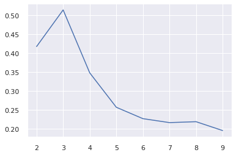

```python
# find silhouette score for clusters 2 to 9 and visulaize it
sil_score = []  # Create empty list
cluster_list = list(range(2, 10))  # Creating a list of range from 2 to 10
for n_clusters in cluster_list:
    #clusterer = KMeans(n_clusters=n_clusters)  # Initializing KMeans algorithm
    clusterer =AgglomerativeClustering(n_clusters=n_clusters, affinity="euclidean", linkage="ward")
    preds = clusterer.fit_predict((ccdattrscaled))  # Predicting on the data
    # centers = clusterer.cluster_centers_
    score = silhouette_score(ccdattrscaled, preds)  # Cacalculating silhouette score
    sil_score.append(score)  # Appending silhouette score to empty list created above
    print("For n_clusters = {}, silhouette score is {}".format(n_clusters, score))

plt.plot(cluster_list, sil_score)
```

Looks like the best score is at cluster = 3. I would go with that.

Once let's visulize the dendrogram cut for ward linkage in the below plot. I would like to cut at 40 get 3 clusters.

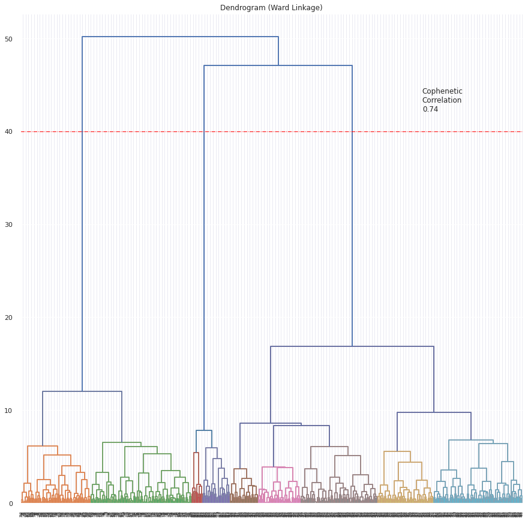

```python
# list of linkage methods
linkage_methods = ["ward"]

# lists to save results of cophenetic correlation calculation
compare_cols = ["Linkage", "Cophenetic Coefficient"]

# to create a subplot image
fig, axs = plt.subplots(len(linkage_methods), 1, figsize=(15, 15))

# We will enumerate through the list of linkage methods above
# For each linkage method, we will plot the dendrogram and calculate the cophenetic correlation
for i, method in enumerate(linkage_methods):
    Z = linkage(ccdattrscaled, metric="euclidean", method=method)

    dendrogram(Z, ax=axs)
    axs.set_title(f"Dendrogram ({method.capitalize()} Linkage)")

    coph_corr, coph_dist = cophenet(Z, pdist(ccdattrscaled))
    axs.annotate(
        f"Cophenetic\nCorrelation\n{coph_corr:0.2f}",
        (0.80, 0.80),
        xycoords="axes fraction",
    )
dendrogram(Z, color_threshold=7.3)
plt.axhline(y=40, c="red", lw=1, linestyle="dashdot")
```

**Applying Hierarchical Clustering**

```python
HCmodel = AgglomerativeClustering(n_clusters=3, affinity="euclidean", linkage="ward")
HCmodel.fit(ccdattrscaled)
```

```
AgglomerativeClustering(n_clusters=3)
```

We have created 3 clusters and fitted that on scaled dataset. Let's add label column to the original, attr (the one with features only) and scaled dataframes.

As it was done in k-means, let's create 3 new datasets with _h version so the original datasets would not change.

```python
# creating _h version of original datasets to use further in k-means
ccd_h = ccd.copy()
ccdattr_h = ccdattr.copy()
ccdattrscaled_h = ccdattrscaled.copy()
```

```python
# adding hierarchical cluster labels to the original and scaled dataframes
ccd_h["HC_Clusters"] = HCmodel.labels_
ccdattr_h["HC_Clusters"] = HCmodel.labels_
ccdattrscaled_h["HC_Clusters"] = HCmodel.labels_
```

Let's check how the original dataset looks

```python
ccd_h.head()
```

|  | Customer Key | Avg_Credit_Limit | Total_Credit_Cards | Total_visits_bank | Total_visits_online | Total_calls_made | HC_Clusters |
| --- | --- | --- | --- | --- | --- | --- | --- |
| 0 | 87073 | 100000 | 2 | 1 | 1 | 0 | 0 |
| 1 | 38414 | 50000 | 3 | 0 | 10 | 9 | 1 |
| 2 | 17341 | 50000 | 7 | 1 | 3 | 4 | 0 |
| 3 | 40496 | 30000 | 5 | 1 | 1 | 4 | 0 |
| 4 | 47437 | 100000 | 6 | 0 | 12 | 3 | 2 |

Looks as expected.

**Cluster Profiling**

Let's create some stats on this by grouping on clusters.

```python
# calculating mean by grouping at cluster number
cluster_profile_h = ccd_h.groupby("HC_Clusters").mean()
```

Add the count to each cluster

```python
# adding another field in dataset for count
cluster_profile_h["count_in_each_segments"] = (
    ccd_h.groupby("HC_Clusters")["Customer Key"].count().values
)
```

```python
# let's display cluster profiles
cluster_profile_h.style.highlight_max(color="lightgreen", axis=0)
```

| HC_Clusters | Customer Key | Avg_Credit_Limit | Total_Credit_Cards | Total_visits_bank | Total_visits_online | Total_calls_made | count_in_each_segments |
| --- | --- | --- | --- | --- | --- | --- | --- |
| 0 | 54895.745455 | 33851.948052 | 5.516883 | 3.493506 | 0.979221 | 1.994805 | 385 |
| 1 | 55213.568889 | 12151.111111 | 2.422222 | 0.937778 | 3.546667 | 6.857778 | 225 |
| 2 | 56708.760000 | 141040.000000 | 8.740000 | 0.600000 | 10.900000 | 1.080000 | 50 |

Original dataset has been divided into clusters with counts of 385, 225 and 50. Most of the highest mean values fall into cluster 2. Cluster 1 has lowest values except total calls made.

Next, let's plot each attribute by their clusters. First we try on scaled dataset and then original. Both should be similar or very close, but let's check it out.

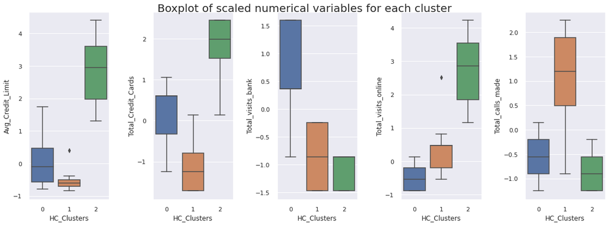

```python
# plotting scaled dataset
fig, axes = plt.subplots(1, 5, figsize=(16, 6))
fig.suptitle("Boxplot of scaled numerical variables for each cluster", fontsize=20)
counter = 0
for ii in range(5):
    sns.boxplot(
        ax=axes[ii],
        y=ccdattrscaled_h[list(ccdattrscaled_h.columns)[counter]],
        x=ccdattrscaled_h["HC_Clusters"],
    )
    counter = counter + 1

fig.tight_layout(pad=2.0)
```

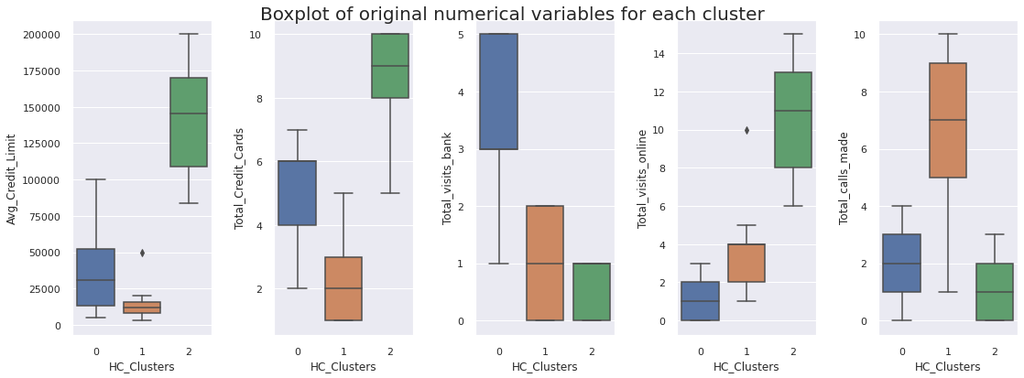

```python
# plotting original dataset
fig, axes = plt.subplots(1, 5, figsize=(16, 6))
fig.suptitle("Boxplot of original numerical variables for each cluster", fontsize=20)
counter = 1
for ii in range(5):
    sns.boxplot(ax=axes[ii], y=ccd_h[list(ccd.columns)[counter]], x=ccd_h["HC_Clusters"])
    counter = counter + 1

fig.tight_layout(pad=2.0)
```

```python
# running describe on attr dataset
ccdattr_h.groupby("HC_Clusters").describe().T
```

|  | HC_Clusters | 0 | 1 | 2 |
| --- | --- | --- | --- | --- |
| Avg_Credit_Limit | count | 385.000000 | 225.000000 | 50.000000 |
|  | mean | 33851.948052 | 12151.111111 | 141040.000000 |
|  | std | 22156.084628 | 5248.665741 | 34457.877272 |
|  | min | 5000.000000 | 3000.000000 | 84000.000000 |
|  | 25% | 13000.000000 | 8000.000000 | 108750.000000 |
|  | 50% | 31000.000000 | 12000.000000 | 145500.000000 |
|  | 75% | 52000.000000 | 16000.000000 | 170000.000000 |
|  | max | 100000.000000 | 50000.000000 | 200000.000000 |
| Total_Credit_Cards | count | 385.000000 | 225.000000 | 50.000000 |
|  | mean | 5.516883 | 2.422222 | 8.740000 |
|  | std | 1.141249 | 1.111805 | 1.274715 |
|  | min | 2.000000 | 1.000000 | 5.000000 |
|  | 25% | 4.000000 | 1.000000 | 8.000000 |
|  | 50% | 6.000000 | 2.000000 | 9.000000 |
|  | 75% | 6.000000 | 3.000000 | 10.000000 |
|  | max | 7.000000 | 5.000000 | 10.000000 |
| Total_visits_bank | count | 385.000000 | 225.000000 | 50.000000 |
|  | mean | 3.493506 | 0.937778 | 0.600000 |
|  | std | 1.134490 | 0.804920 | 0.494872 |
|  | min | 1.000000 | 0.000000 | 0.000000 |
|  | 25% | 3.000000 | 0.000000 | 0.000000 |
|  | 50% | 3.000000 | 1.000000 | 1.000000 |
|  | 75% | 5.000000 | 2.000000 | 1.000000 |
|  | max | 5.000000 | 2.000000 | 1.000000 |
| Total_visits_online | count | 385.000000 | 225.000000 | 50.000000 |
|  | mean | 0.979221 | 3.546667 | 10.900000 |
|  | std | 0.856704 | 1.220656 | 2.880264 |
|  | min | 0.000000 | 1.000000 | 6.000000 |
|  | 25% | 0.000000 | 2.000000 | 8.000000 |
|  | 50% | 1.000000 | 4.000000 | 11.000000 |
|  | 75% | 2.000000 | 4.000000 | 13.000000 |
|  | max | 3.000000 | 10.000000 | 15.000000 |
| Total_calls_made | count | 385.000000 | 225.000000 | 50.000000 |
|  | mean | 1.994805 | 6.857778 | 1.080000 |
|  | std | 1.428860 | 1.994914 | 0.876915 |
|  | min | 0.000000 | 1.000000 | 0.000000 |
|  | 25% | 1.000000 | 5.000000 | 0.000000 |
|  | 50% | 2.000000 | 7.000000 | 1.000000 |
|  | 75% | 3.000000 | 9.000000 | 2.000000 |
|  | max | 4.000000 | 10.000000 | 3.000000 |

# **7. PCA**

As there are already very few dimensions, so will not try to use PCA to reduce further dimensions. However, would like to use PCA to visualize the clusters that were created earlier. I will use it for hierarchical clusters for visualization.

```python
# as we can visualize in 2 dimensions, setting the number of components to 2
pca = PCA(n_components=2)

# transforming data and storing results in a dataframe
X_reduced_pca = pca.fit_transform(ccdattrscaled_h)
reduced_df_pca = pd.DataFrame(
    data=X_reduced_pca, columns=["Component 1", "Component 2"]
)
```

```python
# checking the amount of variance explained
pca.explained_variance_ratio_.sum()
```

```
0.8340792803324297
```

First 2 principal components explain the 83% of data.

Plotting the clusters next.

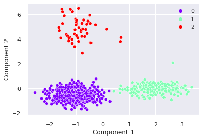

```python
# let's plot the clusters
sns.scatterplot(
    data=reduced_df_pca,
    x="Component 1",
    y="Component 2",
    hue=ccd_h["HC_Clusters"],
    palette="rainbow",
)
plt.legend(bbox_to_anchor=(1, 1))
```

Clusters look well segregated. Cluster 0 shows the more data compare to other two. Can clearly see couple of outliers in cluster 1 as it was observed earlier. Clsuter 2 has less records and at higher values of y axis.

# **8. K-means vs Hierarchical Clustering**

We have successfully done K-means and Hierarchical clustering in previous sections.

Let's compare both the techniques on different points below.

**1. Time taken by each technique -**

*K-means* - it was very quick, creating elbow curve, finding out silhouette score, apply to k-means algorithim, all took less than 10 seconds.  
*Hierarchical* - it took much longer, finding Cophenetic correlation, creating dendograms, silhouette score, apply to hierarchical, all took almost 3 minutes.

**2. Distinct clusters comparison -**

*K-means* - tried with number of clusters as 3 and 4, and by checking their eblow and silhouette score, 3 turned out to be the best.

*Hierarchical* - tired different distance metrics and linkage and found linkage and eucledien distance the best and after checking silhouette scores of different number of clusters, 3 came out to be the best.

Both gave the best at number of clusters = 3

**3. Silhouette Scores Comparison -**

*K-means* - for 3 clusters, it came out 0.5157

*Hierarchical* - for 3 clusters, it came out 0.5147

Both were very close.

**4. Observations in the similar clusters in both algorithms -**

Both of the algorightms got 3 clusters, with very similar counts in each clusters. Both have cluster 0 with mid-range customers, cluster 1 with low-range customers and cluster 2 with high-range customers in terms of their credit limits and number of cards they carry. Also, both have highest counts in cluster 0 followed by cluster 1 and then cluster 2.

Overall, both the algorithms gave very close results in segmentaing customers.

# **9. Summary of Insights & Recommendations**

As part of this project, we have analyzed the customer data of AllLife Bank who wants improve their credit card customer business. The objective of the project was to identify different segments in the existing customer, based on their spending patterns as well as past interaction with the bank, using clustering algorithms.

To achieve the goal, we tried k-means and hierarchical algorithms. We tried different methods to find best number of clusters based for these algorithms and segregated data into 3 different clusters. Both algorithms gave very close results.

While doing cluster analysis, I found that, mainly the clusters are segregated based on the way customer communicate with the bank. Customers can communicate via 3 ways.

1) Visting the bank in-person (cluster 0)

2) Visting the bank online (cluster 2)

3) By calling the bank (cluster 1)

Cluster 0 customers which like to visit the bank in-person are the maximum among any other clusters. They have mid range credit limit and number of credit cards which makes me guess these are middle class people with mid range income. These customers do not bring much business to the bank but as they are high in numbers its still profitable to the bank. To get more profit out of such customers, bank should think about reducing the overhead like keeping more stuff because of such customers. One way is to encourage them to use more online banking by advertising about it everytime they visit the bank, waive some fees if they do business online, setup automatic utility bill pays etc. so they get habit of using online. Also, bank can try to offer them good credit card rewards, huge points when sign up for new credit card, free family member credit card etc. so they use credit card more and bank can get more business. Bank should also look into the reasons behind their multiple visits, do they just visit to say pay bills or visit with some issues with their card or questions. Based on that, they can train their staff so customers visit less.

Cluster 2 customers visting online the most are the least in number, however they have maximum amount of credit limit and highest number of credit cards. These customers are the premium customers because they have more limits and cards so assuming these are higher income customers with better credit scores. And they use online resources of the bank and not actually human hours, so much less overhead to the bank. The bank should do their best to keep such customers. To upsell such customers, they could offer platinum kind of credit cards that has higher fees and has good rewards on luxury items/travels. Also, bank could keep improving their online website/app to they keep using without any complains.

Note - if dataset can get more features like customer's income and revenue to the bank, what kind of credit cards they have etc. then it would help to provide more in-depth recommendations to the marketing team.